# Lab03

Author

Marc Caramoan

Published

August 12, 20204

```r
library(tidyverse)
library(ggplot2)
```

## 1 Dishonest Dices

```r
y = c(1, 15, 42, 32, 10) # input the observed counts
x = 0:4 # define the corresponding groups
# getting no even on all 4 is (1/2)^4 - getting 1 even is (1/2)^1
p = dbinom(x, size = 4, prob = 1/2)
p
```

```
[1] 0.0625 0.2500 0.3750 0.2500 0.0625
```

```r
e_y = sum(y) * p
e_y # looks like all expected values ate greater or equal to 5
```

```
[1]  6.25 25.00 37.50 25.00  6.25
```

then we want to calculate test stat

```r
t0 = sum( (y - e_y)^2/e_y )
t0
```

```
[1] 13.16
```

so here we get a t stat of 13.16. now we want to find p value using chisq test

```r
pchisq(t0, df = 4, lower.tail = FALSE) # lower tail is false as we want to find area on lower end
```

```
[1] 0.0105199
```

so we get 0.0105 as p-value, which is quite small. we should be rejecting the null hypothesis as it is a really small chance to get this value

H_0: y follows a binom distribution with n = 4, p = 1/2

H_1; y does not follow a binom distribution.

t0 = 13.16. p-val = 0.0105199. we reject null as 0.01 < 0.05

## 2 3.2 - mammograms

suppose: among 100,000 women with neg mammograms, 20 will have breast cancer. among 100 women with pos mammograms, 10 with have breast cancer. is there a relationship between a pos or neg mamogram and having breast cancer?

```r
x = matrix(c(10, 20, 90, 99980), ncol = 2)
colnames(x) = c("Breast cancer: yes", "Breast cancer: no")
rownames(x) = c("Mammogram: positive", "Mammogram: negative")
x
```

```
                    Breast cancer: yes Breast cancer: no
Mammogram: positive                 10                90
Mammogram: negative                 20             99980
```

```r
a = x[1,1]
b = x[1,2]
c = x[2,1]
d = x[2,2]
RR = a*(c+d) / (c*(a+b))
RR
```

```
[1] 500
```

is it appropriate to use a relative risk to quantify the relationship between the risk factor (mammogram result) and disease (breast cancer).

relative risk is equal to the ratio of two conditional probabilities:

$$RR = \frac{P(D^+|R^+)}{P(D^+|R^-)}$$

here we got 500, which means that we are 500 times more likely to get breast cancer if we test positive for the mammogram compared to if we test negative.

the odds ratio is simple as well:

```r
OR = a*d/(b*c)
OR
```

```
[1] 555.4444
```

women who test positive has 555 times higher odds to get breast cancer compared to those who test negative

to calculate the confidence interval for odds ratio, we have to find the log odds confidence interval and then exponentiate it.

```r
ORse = sqrt(1/a + 1/b + 1/c + 1/d)
ORse
```

```
[1] 0.4013989
```

```r
logOR = log(OR, exp(1))
logOR
```

```
[1] 6.319769
```

```r
conf_int = c((logOR - 1.96 * ORse), (logOR + 1.96 * ORse))
conf_int
```

```
[1] 5.533027 7.106511
```

```r
conf_int = exp(conf_int)
conf_int
```

```
[1]  252.9082 1219.8834
```

## 3 3.3 - soccer goals

```r
goals <- c(
  1, 0, 0, 1, 1, 0, 0, 0, 1, 1, 2, 2, 4, 0, 10,
  0, 1, 1, 2, 3, 0, 4, 1, 3, 6, 0, 1, 0, 10, 1,
  2, 1, 0, 1, 1, 2, 3, 3, 3, 1, 2, 0, 0, 0, 0,
  1, 1, 1, 1, 1, 2, 0, 1, 0, 2, 2, 0, 1, 2, 1,
  1, 0, 1, 1, 0, 2, 2, 1, 0, 5, 2, 1, 4, 1, 1,
  0, 0, 1, 3, 0, 1, 0, 1, 2, 2, 0, 2, 1, 1, 1,
  0, 1, 0, 1, 2, 1, 2, 0, 2, 1, 0, 1, 5, 2
)
n = 104 # number of games
goal_range = 0:max(goals)
goal_factor = factor(goals, levels = goal_range)
goal_occurences = table(goal_factor)
goal_occurences
```

```
goal_factor
 0  1  2  3  4  5  6  7  8  9 10
30 40 20  6  3  2  1  0  0  0  2
```

```r
total_goals = sum(goals)
total_goals
```

```
[1] 146
```

so here, there are 104 games recorded, and there were a total of 146 goals. we can try to visualize this.

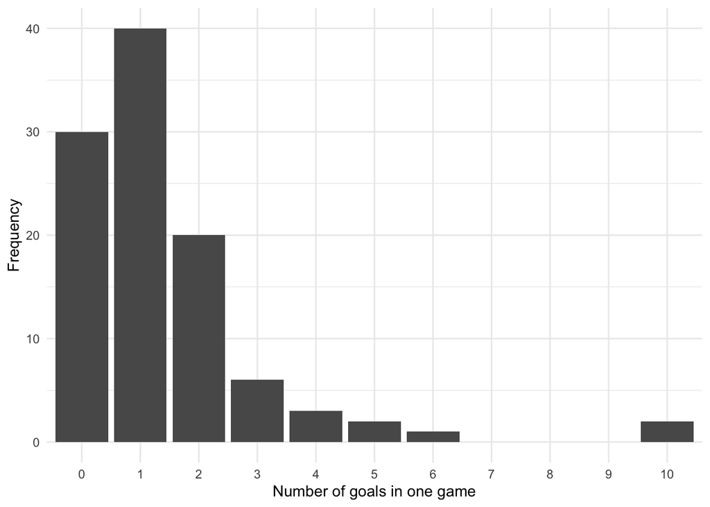

```r
# first need to convert table into dataframe for use in ggplot2
goals_df = goal_occurences |> as.data.frame()
goals_df |> colnames() = c("Goals", "Frequency")

# then we can plot the histogram

goals_df |> ggplot() + aes(x = Goals, y = Frequency) + geom_bar(stat = "identity") + labs(x = "Number of goals in one game", y = "Frequency") + theme_minimal()
```

now that we can see what our frequency of goals per game looks like, it easier to think about testing if the number of goals scored per game follows a Poisson distribution.

we would need to first find the probabilities for each outcome under a Poisson distribution, then find the squared differences between the expected number of goals per game and the actual to retrieve our t-stat.

### 3.1 what is a poisson distribution?

a poisson random variable represents the probability of a given number of events occurring in a fixed interval - if these events occur independently with some known average rate $\lambda$ per unit of time. its probability mass function is:

$$P(X=k) = e^-\lambda \frac{\lambda^k}{k!} \text{ for }k=0,1,2 \dots$$

now lambda $\lambda$ is also known as the sample mean. the mean we want to find here is the average number of goals per game.

```r
lambda = mean(goals)
lambda
```

```
[1] 1.403846
```

now we can just simply calculate the probabilities for each number 0 - 10 occuring in a poisson distribution:

```r
poisson_probs = dpois(0:10, lambda)

poisson_probs
```

```
 [1] 2.456503e-01 3.448553e-01 2.420619e-01 1.132725e-01 3.975431e-02
 [6] 1.116179e-02 2.611572e-03 5.237493e-04 9.190793e-05 1.433607e-05
[11] 2.012563e-06
```

now we want to calculate the expected number of games with these goals, given that the total number of games is 104.

```r
expected_goals = poisson_probs * 104
expected_goals
```

```
 [1] 2.554763e+01 3.586495e+01 2.517444e+01 1.178034e+01 4.134448e+00
 [6] 1.160826e+00 2.716035e-01 5.446993e-02 9.558424e-03 1.490951e-03
[11] 2.093066e-04
```

```r
expected_table = data.frame(
  Goals = goals_df$Goals,
  Probability = round(poisson_probs, 5),
  Expected = round(expected_goals, 5),
  Actual = goals_df$Frequency
)
expected_table
```

| Goals | Probability | Expected | Actual |
| --- | --- | --- | --- |
| 0 | 0.24565 | 25.54763 | 30 |
| 1 | 0.34486 | 35.86495 | 40 |
| 2 | 0.24206 | 25.17444 | 20 |
| 3 | 0.11327 | 11.78034 | 6 |
| 4 | 0.03975 | 4.13445 | 3 |
| 5 | 0.01116 | 1.16083 | 2 |
| 6 | 0.00261 | 0.27160 | 1 |
| 7 | 0.00052 | 0.05447 | 0 |
| 8 | 0.00009 | 0.00956 | 0 |
| 9 | 0.00001 | 0.00149 | 0 |

[output cut: 1 more lines]

```r
exp_combined = expected_table |>
  mutate(Goals = as.character(Goals)) |>
  mutate(Goals = ifelse(as.numeric(Goals) >= 4, "4+", Goals)) |>
  group_by(Goals) |>
  summarise(
    Probability = sum(Probability),
    Expected = sum(Expected),
    Actual = sum(Actual)
  )
exp_combined
```

| Goals | Probability | Expected | Actual |
| --- | --- | --- | --- |
| 0 | 0.24565 | 25.54763 | 30 |
| 1 | 0.34486 | 35.86495 | 40 |
| 2 | 0.24206 | 25.17444 | 20 |
| 3 | 0.11327 | 11.78034 | 6 |
| 4+ | 0.05414 | 5.63261 | 8 |